# Data Analysis Replication Assignment

Phil Queller

4/11/2020

# Background

This paper looks into differecnes in learning ability between male and female guppies in two learning tasks: a detour task and a maze task. Male and female guppies differ in various asepcects of behavior and ecology (e.g. colorful males face higher predation) and the researcheres wanted to know if males and females have evolved different cognitive abilities as a result.

The detour task consists of a tank with a shoal group (reward) on one end and the focal fish on the other. Between them is a transparent divider the fish must detour around to reach the shoal. For the detour task, the researchers made the divider either fully transparent or semi-transparent (opqaue). Each fish was tested in either the transparent or opaque treatment and went throught the task 5 times. The researchers measured two variables in this task: overal solve time and time spent at the barrier.

The maze task again consists of a shoal group (reward) on one side and a focal fish on the other. Between them are two barriers, each with 2 door choice, one of which is blocked. The focal fish must choose the correct door at each barrier to reach the reward. Each fish is tested 5 times to look for improvements in solve time and for overall accuracy.

This experiemnt uses two datasets, one for each task. Below I will summarize the visualazations and analyses I will perform on each dataset:

### Detour:

plots: 1) time to solve task X trial transparent, by sex 2) time to solve task X trial opaque, by sex 3) time in front of barrier X trial transparent, by sex 4) time in front of barrier X trial opaque, by sex

analyses: 5) LMM with time to solve task as a function of trial, sex, and barrier type 6) LMM with time in front of barrier as a function of trial, sex, and barrier type

### Maze:

plots: 1) time to solve task X trial, by sex 2) mean accuracy X trial, by sex

analyses: 3) LMM with time to solve task as a function of trial and sex 4) GLMM with door choice (correct or incorrect) as a function of trial, sex, and sector (first or second barrier) 5) Use data from 4) to split sexes apart and run 2 idependent GLMMs as in 4) but within each sex. 5) t ttest to compare male mean accuracy on trials (2-5) agaisnt chance () 6) t ttest to compare female mean accuracy on trials (2-5) agaisnt chance ()

```r
library(tidyverse)
library(lme4)
library(radiant)
library(lmerTest)
detour <- read_csv("/Users/queller/Desktop/ADA_detour.csv")
head(detour)
```

```
## # A tibble: 6 x 8
##   subject type.of.barrier experiment sex   type  trial time.front.barr…
##   <chr>   <chr>           <chr>      <chr> <chr> <dbl>            <dbl>
## 1 subj01  opaque          1b         F     rete      1               26
## 2 subj02  opaque          1b         F     rete      1                6
## 3 subj03  opaque          1b         F     rete      1               40
## 4 subj04  opaque          1b         F     rete      1               14
## 5 subj05  opaque          1b         F     rete      1                4
## 6 subj06  opaque          1b         F     rete      1               32
## # … with 1 more variable: latency.solve.task <dbl>
```

```r
maze <- read_csv("/Users/queller/Desktop/ADA_maze.csv")
head(maze)
```

```
## # A tibble: 6 x 6
##   fish.id sex   trial time.solve.task first.door second.door
##   <chr>   <chr> <dbl>           <dbl>      <dbl>       <dbl>
## 1 subj01  F         1             168          1           1
## 2 subj02  F         1             111          0           1
## 3 subj03  F         1             443          0           1
## 4 subj04  F         1             157          1           0
## 5 subj05  F         1             175          0           1
## 6 subj06  F         1             240          1           1
```

# Detour

First I will work with the detour data set. Ill start by making new data frames with descriptive statistics I’ll then plot. I want to plot mean solve time and mean time at barrier by trial and by sex.

## Descriptive stats and plots

```r
#mean solve time and time at barrier for the transparent barrier
transparent_means <- detour %>%
  filter(type.of.barrier == "transparent") %>%
  group_by(trial, sex, type.of.barrier) %>%
  mutate(barrier_plus_one = time.front.barrier + 1) %>%
  summarize(mean_latency = mean(latency.solve.task),
            se_latency = se(latency.solve.task),
            mean_barrier = mean(barrier_plus_one),
            se_barrier = se(barrier_plus_one))



#mean solve time and time at barrier for the opaque barrier
opaque_means <- detour %>%
   filter(type.of.barrier == "opaque") %>%
   group_by(trial, sex, type.of.barrier) %>%
   mutate(barrier_plus_one = time.front.barrier + 1) %>%
   summarize(mean_latency = mean(latency.solve.task),
            se_latency = se(latency.solve.task),
            mean_barrier = mean(barrier_plus_one),
            se_barrier = se(barrier_plus_one))
```

Now make plots for solve time for both opaque and transaprent variations.

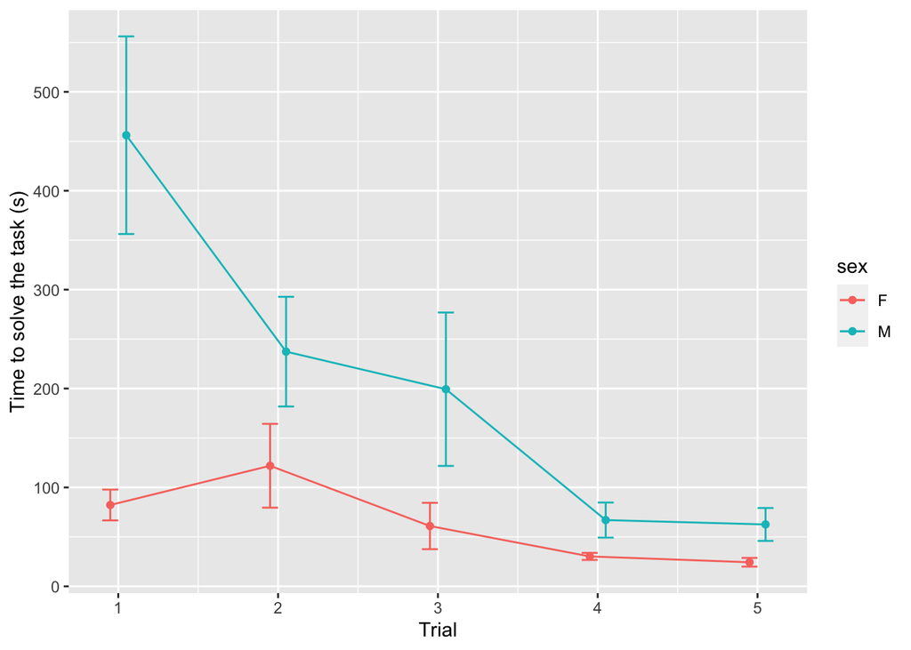

```r
transparent_means %>% ggplot(aes(x = trial, y = mean_latency, group = sex, color = sex)) +
  geom_line(position =    position_dodge(.2)) +
  geom_point(position =    position_dodge(.2)) +
  geom_errorbar(aes(ymin = mean_latency - se_latency, ymax= mean_latency + se_latency), width=.2, position =    position_dodge(.2)) +
  ylab("Time to solve the task (s)") +
  xlab("Trial")
```

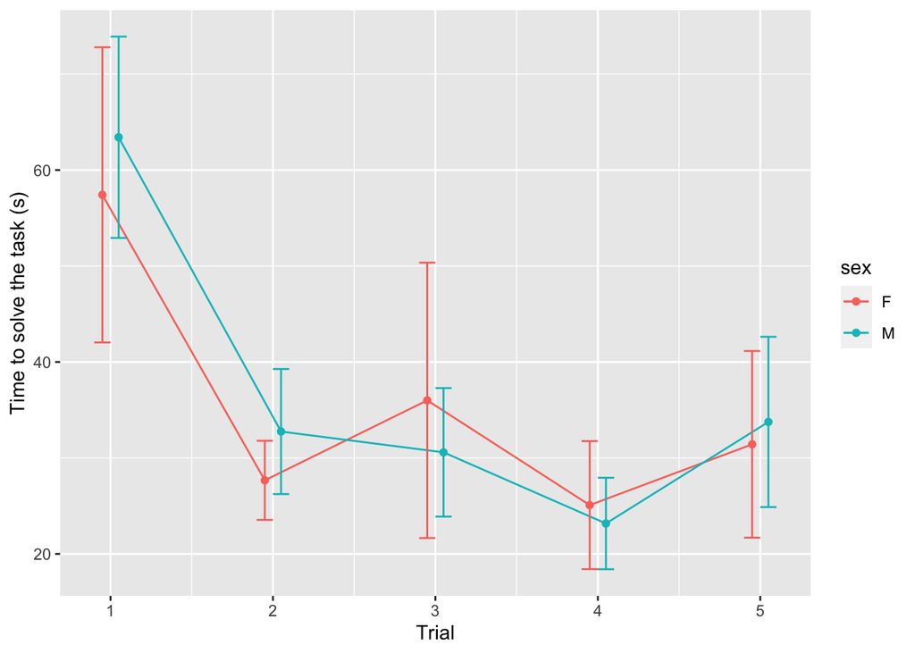

```r
opaque_means %>% ggplot(aes(x = trial, y = mean_latency, group = sex, color = sex)) +
  geom_line(position = position_dodge(.2)) +
  geom_point(position = position_dodge(.2)) +
  geom_errorbar(aes(ymin = mean_latency - se_latency, ymax= mean_latency + se_latency), width=.2, position = position_dodge(.2)) +
  ylab("Time to solve the task (s)") +
  xlab("Trial")
```

Compare to the published figures:

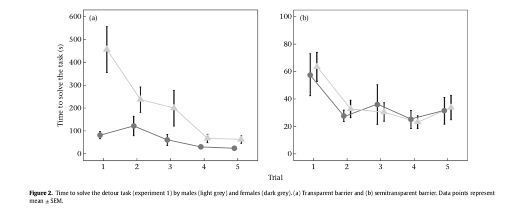

```r
knitr:: include_graphics ("1.png")
```

Now I’ll make plots for time in front of barrier for opaque and transparent variations.

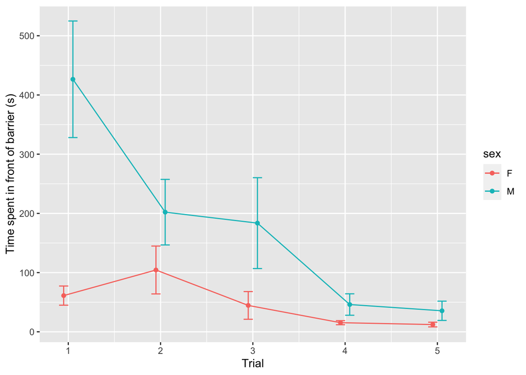

```r
transparent_means %>% ggplot(aes(x = trial, y = mean_barrier, group = sex, color = sex)) +
  geom_line(position = position_dodge(.2)) +
  geom_point(position = position_dodge(.2)) +
  geom_errorbar(aes(ymin = mean_barrier - se_barrier, ymax= mean_barrier + se_barrier), width=.2, position =    position_dodge(.2)) +
  ylab("Time spent in front of barrier (s)") +
  xlab("Trial")
```

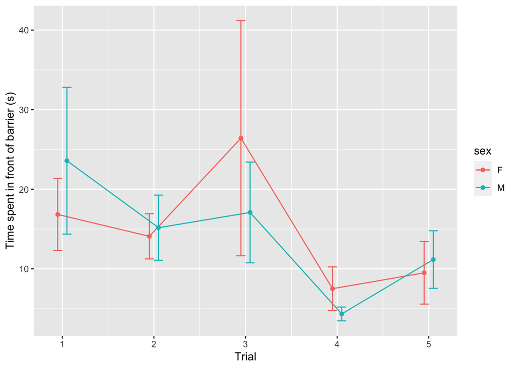

```r
opaque_means %>% ggplot(aes(x = trial, y = mean_barrier, group = sex, color = sex)) +
  geom_line(position = position_dodge(.2)) +
  geom_point(position = position_dodge(.2)) +
  geom_errorbar(aes(ymin = mean_barrier - se_barrier, ymax= mean_barrier + se_barrier), width=.2, position = position_dodge(.2)) +
  ylab("Time spent in front of barrier (s)") +
  xlab("Trial")
```

Compare to the published figures:

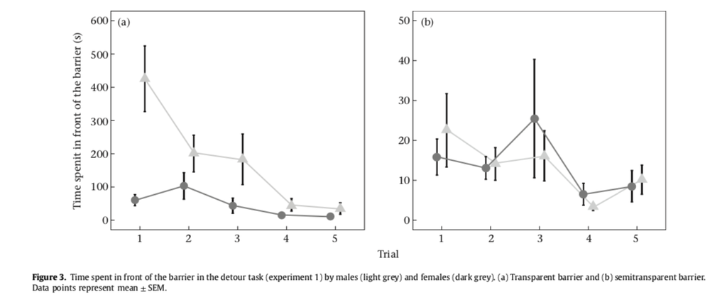

```r
knitr:: include_graphics ("2.png")
```

## Analyses

I’ll fit a mixed linear model with solve time as the dependent variable, barier type, sex, and trial, as fixed effects, and subject ID as a random effect.

```r
detour_fit <- lmer(log(latency.solve.task) ~ trial + sex + type.of.barrier + (1 | subject), data = detour)
summary(detour_fit)
```

```
## Linear mixed model fit by REML. t-tests use Satterthwaite's method [
## lmerModLmerTest]
## Formula: log(latency.solve.task) ~ trial + sex + type.of.barrier + (1 |
##     subject)
##    Data: detour
##
## REML criterion at convergence: 661.7
##
## Scaled residuals:
##      Min       1Q   Median       3Q      Max
## -2.28370 -0.58771 -0.02384  0.50952  2.67682
##
## Random effects:
##  Groups   Name        Variance Std.Dev.
##  subject  (Intercept) 0.1144   0.3382
##  Residual             0.8019   0.8955
## Number of obs: 240, groups:  subject, 48
##
## Fixed effects:
##                             Estimate Std. Error        df t value Pr(>|t|)
## (Intercept)                  3.82955    0.17946 134.08453  21.339  < 2e-16 ***
## trial                       -0.28296    0.04087 191.00000  -6.923 6.54e-11 ***
## sexM                         0.53058    0.15131  45.00000   3.507  0.00104 **
## type.of.barriertransparent   0.82423    0.15131  45.00000   5.447 2.05e-06 ***
## ---
## Signif. codes:  0 '***' 0.001 '**' 0.01 '*' 0.05 '.' 0.1 ' ' 1
##
## Correlation of Fixed Effects:
##             (Intr) trial  sexM
## trial       -0.683
## sexM        -0.422  0.000
## typ.f.brrrt -0.422  0.000  0.000
```

Let’s compare these findings with the original paper. For the LMM on solve time in the detour task, the researchers report significant effects of trial (p < 0.001), barrier type (p < 0.001), and sex (p < 0.001). My LMM reveals the same relationships as the original paper, as seen by the p-values shown in the summary stats of the model.

Now I’ll fit another model to with time.at.barrier as the dependent variable. The researchers log transformed these values, but a log transformation won’t work for values of 0, which exist in this variable. So I will create a new variable called barrier_plus_one where I add 1 to every value, keeping their relationships the same while allowing a log transformation.

```r
df <- detour %>%  mutate(barrier_plus_one = time.front.barrier + 1)
```

Now run the LMM on time at barrier as a function of trial, sex, and barrier type:

```r
detour_fit <- lmer(log(barrier_plus_one) ~ trial + sex + type.of.barrier + (1 | subject), data = df)
summary(detour_fit)
```

```
## Linear mixed model fit by REML. t-tests use Satterthwaite's method [
## lmerModLmerTest]
## Formula: log(barrier_plus_one) ~ trial + sex + type.of.barrier + (1 |
##     subject)
##    Data: df
##
## REML criterion at convergence: 860.2
##
## Scaled residuals:
##      Min       1Q   Median       3Q      Max
## -2.63659 -0.64920  0.02852  0.65826  2.65693
##
## Random effects:
##  Groups   Name        Variance Std.Dev.
##  subject  (Intercept) 0.2713   0.5209
##  Residual             1.8557   1.3623
## Number of obs: 240, groups:  subject, 48
##
## Fixed effects:
##                             Estimate Std. Error        df t value Pr(>|t|)
## (Intercept)                  2.85051    0.27377 133.21379  10.412  < 2e-16 ***
## trial                       -0.39625    0.06218 191.00000  -6.373 1.36e-09 ***
## sexM                         0.52772    0.23138  45.00000   2.281   0.0274 *
## type.of.barriertransparent   1.37075    0.23138  45.00000   5.924 4.05e-07 ***
## ---
## Signif. codes:  0 '***' 0.001 '**' 0.01 '*' 0.05 '.' 0.1 ' ' 1
##
## Correlation of Fixed Effects:
##             (Intr) trial  sexM
## trial       -0.681
## sexM        -0.423  0.000
## typ.f.brrrt -0.423  0.000  0.000
```

The findings from the LMM on time at barrier concur with the results in the orginal paper. They found signficiant effects of trial (p < 0.001), sex (p < 0.020), and barrier type (p < 0.001).

# Maze

Now I will work with the maze data set. Ill start by making new data frames with descriptive statistics Ill then plot. I want to plot mean solve time and mean accuracy by trial.

## Descriptive stats and plots

For mean solve time I need to create a dataframe with the average solve time by trial and sex with the standard error:

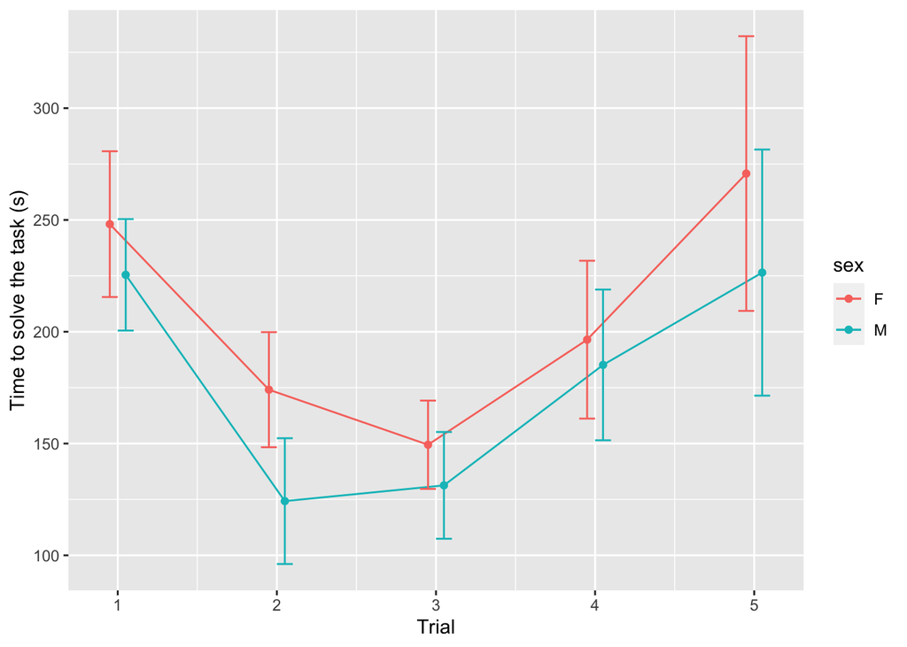

```r
maze_solveTime_mean <- maze %>%
  group_by(trial, sex) %>%
  summarize(mean_latency = mean(time.solve.task), se_latency = se(time.solve.task))


maze_solveTime_mean %>% ggplot(aes(x = trial, y = mean_latency, group = sex, color = sex)) +
  geom_line(position =    position_dodge(.2)) +
  geom_point(position =    position_dodge(.2)) +
  geom_errorbar(aes(ymin = mean_latency - se_latency, ymax= mean_latency + se_latency), width=.2, position =  position_dodge(.2)) +
  ylab("Time to solve the task (s)") +
  xlab("Trial")
```

Now make a plot of mean accuracy by trial by sex

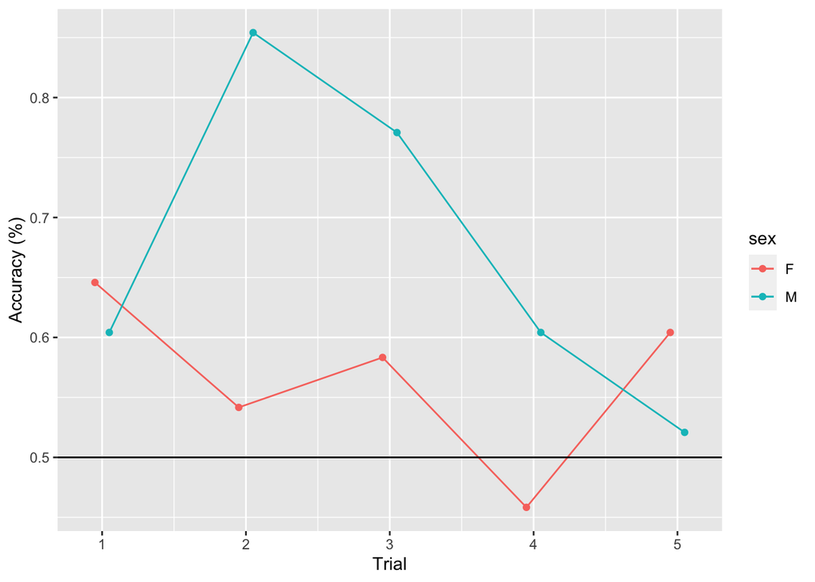

```r
accuracy_plot <- maze %>%
  pivot_longer(cols=c("first.door","second.door"), names_to = "door") %>%
  group_by(trial,sex) %>%
  summarize(correct.choices = sum(value),
            total_choices = n(),
            accuracy_percent = (correct.choices/total_choices),
            se_accuracy_percent = se(accuracy_percent)
            )

accuracy_plot %>% ggplot(aes(x = trial, y = accuracy_percent, group = sex, color = sex)) +
  geom_line(position = position_dodge(.2)) +
  geom_point(position = position_dodge(.2)) +
  geom_errorbar(aes(ymin = accuracy_percent - se_accuracy_percent, ymax= accuracy_percent + se_accuracy_percent), width=.2, position = position_dodge(.2)) +
  geom_hline(yintercept = 0.5) +
  ylab("Accuracy (%)") +
  xlab("Trial")
```

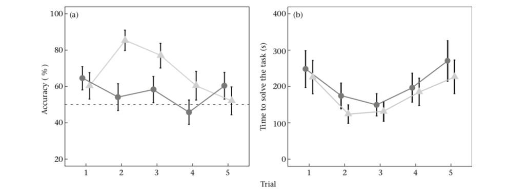

```r
knitr:: include_graphics ("3.png")
```

## Analyses

Now I’ll run a LMM onn solve time as a function of trial and sex.

```r
maze_fit <- lmer(log(time.solve.task) ~ trial + sex + (1 | fish.id), data = maze)
summary(maze_fit)
```

```
## Linear mixed model fit by REML. t-tests use Satterthwaite's method [
## lmerModLmerTest]
## Formula: log(time.solve.task) ~ trial + sex + (1 | fish.id)
##    Data: maze
##
## REML criterion at convergence: 595.6
##
## Scaled residuals:
##      Min       1Q   Median       3Q      Max
## -2.47840 -0.50034  0.03687  0.60983  2.78854
##
## Random effects:
##  Groups   Name        Variance Std.Dev.
##  fish.id  (Intercept) 0.1958   0.4425
##  Residual             0.5551   0.7451
## Number of obs: 240, groups:  fish.id, 48
##
## Fixed effects:
##              Estimate Std. Error        df t value Pr(>|t|)
## (Intercept)   5.08677    0.15230 130.54815  33.400   <2e-16 ***
## trial        -0.01769    0.03401 191.00000  -0.520    0.604
## sexM         -0.23127    0.15991  46.00000  -1.446    0.155
## ---
## Signif. codes:  0 '***' 0.001 '**' 0.01 '*' 0.05 '.' 0.1 ' ' 1
##
## Correlation of Fixed Effects:
##       (Intr) trial
## trial -0.670
## sexM  -0.525  0.000
```

Here we see some difference between my analysis and that of the orignal paper. This LMM shows no effect of sex or trial on solve time. The original paper reported a significant effect of trial (p < 0.001). I’m not sure why. The p values are so far apart I don’t think its a difference that comes from slightly different assumptions built into the model.

To analyze the choice accuracy in the maze I will fit a generalized linear mixed model with door choice (correct or incorrect) as the dependent variable, sex, trial, and door (first or second) as fixed effects, and subject ID as a random effect.

I will need to convert my data from wide to long (first.door and second.door will become ‘door’ with another column for ‘choice’ with a binary variable)

```r
#this is for the model
accuracy_model <- maze %>%
  pivot_longer(cols=c("first.door","second.door"), names_to = "door") %>%
  group_by(sex,door)


maze_fit <- glmer(data = accuracy_model, value ~ sex + door + trial + (1 | fish.id), family = binomial)
summary(maze_fit)
```

```
## Generalized linear mixed model fit by maximum likelihood (Laplace
##   Approximation) [glmerMod]
##  Family: binomial  ( logit )
## Formula: value ~ sex + door + trial + (1 | fish.id)
##    Data: accuracy_model
##
##      AIC      BIC   logLik deviance df.resid
##    639.0    659.9   -314.5    629.0      475
##
## Scaled residuals:
##     Min      1Q  Median      3Q     Max
## -1.6550 -1.1665  0.6563  0.7861  1.0119
##
## Random effects:
##  Groups  Name        Variance Std.Dev.
##  fish.id (Intercept) 0.02045  0.143
## Number of obs: 480, groups:  fish.id, 48
##
## Fixed effects:
##                 Estimate Std. Error z value Pr(>|z|)
## (Intercept)      0.65957    0.26310   2.507   0.0122 *
## sexM             0.44910    0.19515   2.301   0.0214 *
## doorsecond.door -0.01808    0.19019  -0.095   0.9243
## trial           -0.12626    0.06752  -1.870   0.0615 .
## ---
## Signif. codes:  0 '***' 0.001 '**' 0.01 '*' 0.05 '.' 0.1 ' ' 1
##
## Correlation of Fixed Effects:
##             (Intr) sexM   drscn.
## sexM        -0.334
## doorscnd.dr -0.363 -0.001
## trial       -0.780 -0.020  0.001
```

The results of my GLMM on accuracy as a function of trial, sex, and door revealed similar results as the original paper. They report a significant effect of sex (p = 0.041) and no effect of door or trial. In my GLMM trial is approaching significance as well. This may because of slightly different assumptions built into the model parameters between myself and the original paper.

Because there was a significant effect of sex, the researchers ran 2 separate GLMMs for each sex.

```r
male_accuracy <- accuracy_model %>% filter(sex == "M")


maze_fit <- glmer(data = male_accuracy, value ~ door + trial + (1 | fish.id), family = binomial)
```

```
## boundary (singular) fit: see ?isSingular
```

```r
summary(maze_fit)
```

```
## Generalized linear mixed model fit by maximum likelihood (Laplace
##   Approximation) [glmerMod]
##  Family: binomial  ( logit )
## Formula: value ~ door + trial + (1 | fish.id)
##    Data: male_accuracy
##
##      AIC      BIC   logLik deviance df.resid
##    308.2    322.1   -150.1    300.2      236
##
## Scaled residuals:
##     Min      1Q  Median      3Q     Max
## -1.7898 -1.2218  0.6147  0.7163  0.8669
##
## Random effects:
##  Groups  Name        Variance Std.Dev.
##  fish.id (Intercept) 4e-14    2e-07
## Number of obs: 240, groups:  fish.id, 24
##
## Fixed effects:
##                 Estimate Std. Error z value Pr(>|z|)
## (Intercept)      1.24005    0.36417   3.405 0.000661 ***
## doorsecond.door  0.11507    0.27708   0.415 0.677920
## trial           -0.19089    0.09876  -1.933 0.053263 .
## ---
## Signif. codes:  0 '***' 0.001 '**' 0.01 '*' 0.05 '.' 0.1 ' ' 1
##
## Correlation of Fixed Effects:
##             (Intr) drscn.
## doorscnd.dr -0.367
## trial       -0.846 -0.007
## convergence code: 0
## boundary (singular) fit: see ?isSingular
```

The original paper found that a GLMM on male accuracy revealed a significant effect of trial (p = 0.006). In my analysis, trial was approaching significance at p = 0.053.

```r
female_accuracy <- accuracy_model %>% filter(sex == "F")


maze_fit <- glmer(data = female_accuracy, value ~ door + trial + (1 | fish.id), family = binomial)
summary(maze_fit)
```

```
## Generalized linear mixed model fit by maximum likelihood (Laplace
##   Approximation) [glmerMod]
##  Family: binomial  ( logit )
## Formula: value ~ door + trial + (1 | fish.id)
##    Data: female_accuracy
##
##      AIC      BIC   logLik deviance df.resid
##    335.4    349.3   -163.7    327.4      236
##
## Scaled residuals:
##     Min      1Q  Median      3Q     Max
## -1.3181 -1.0955  0.7911  0.8711  1.0125
##
## Random effects:
##  Groups  Name        Variance Std.Dev.
##  fish.id (Intercept) 0.06252  0.25
## Number of obs: 240, groups:  fish.id, 24
##
## Fixed effects:
##                 Estimate Std. Error z value Pr(>|z|)
## (Intercept)      0.54975    0.34195   1.608    0.108
## doorsecond.door -0.13822    0.26302  -0.526    0.599
## trial           -0.06909    0.09308  -0.742    0.458
##
## Correlation of Fixed Effects:
##             (Intr) drscn.
## doorscnd.dr -0.391
## trial       -0.824  0.004
```

As in the origianl paper, I found no effect of trial or door on female accuracy. Original paper reported trial (p = 0.436), door (p = 0.596).

I will also compare average choice accuracy in trials 2-5. I will remove trial 1 as fish have no prior experience with the maze and their accuracy is not expected to differ from chance. I’ll compare average accuracy to accuracy expected by chance (50%). To calculate accuracy for each fish I will count the number of correct choices out of total choices across 4 trials. There are 2 choices per trial, and 4 trials, so 8 total choices. Average choice accuracy will be the number of correct choices divided by 8. I will compare mean accuracy in males and females separatley.

```r
mean_subject_accuracy <- maze %>%
  filter (trial !=1) %>%
  pivot_longer(cols=c("first.door","second.door"), names_to = "door") %>%
  group_by(fish.id) %>%
  summarize(correct.choices = sum(value),
            total_choices = n(),
            accuracy_percent = (correct.choices/total_choices),
            sex = unique(sex))




# make a copy of ^ for males and females to compare to chance (50%)

males <- mean_subject_accuracy %>% filter(sex == "M")
females <- mean_subject_accuracy %>% filter(sex == "F")


t.test(males$accuracy_percent, mu = 0.5, alternative = "greater")
```

```
##
##  One Sample t-test
##
## data:  males$accuracy_percent
## t = 5.5723, df = 23, p-value = 5.706e-06
## alternative hypothesis: true mean is greater than 0.5
## 95 percent confidence interval:
##  0.6298302       Inf
## sample estimates:
## mean of x
##    0.6875
```

```r
t.test(females$accuracy_percent, mu = 0.5, alternative = "greater")
```

```
##
##  One Sample t-test
##
## data:  females$accuracy_percent
## t = 1.0714, df = 23, p-value = 0.1476
## alternative hypothesis: true mean is greater than 0.5
## 95 percent confidence interval:
##  0.4718903       Inf
## sample estimates:
## mean of x
##  0.546875
```

My results confirmed those of the orignal paper: overall accuracy was significantly greater than chance for males (p < 0.001) but not females (0.306).

## Discussion:

Overall I was successful in recreating the plots and analyses of this paper. My visualizations look very similar to the original paper. My analyses were largely similar, although there were a few differences. For example, the LMM on time to solve the maze did not show any significant effects in my model, but it did in the paper. Similarly, in the GLMM on accuracy, the original paper reported only an effect of sex, but my analyses also showed a near-signifcant effect of trial. Also, the original paper found that a GLMM on male accuracy revealed a significant effect of trial (p = 0.006). In my analysis, trial was approaching significance at p = 0.053. Finally, the original paper reported a GLMM on male accuracy revealed a significant effect of trial (p = 0.006). In my analysis, trial was approaching significance at p = 0.053.

If the paper would have included more specific information on the parameters of these tests that might account for some of the differences in our analyses. Also, they weren’t always clear on what analyses was being done. We had to infer which statistical test was done by the stats they report in the results (partiicularly for the mean choice accuracy by sex compared to chance test)